# assignment-02-24300980021-刘俊彦

## Dataset

> The dataset for this homework is derived from the text8 collection, which comes from Wikipedia. Your method will use character-level tokenization and operate over text8 sequences that are each exactly 20 characters long. Only 27 character types are present (lowercase characters and spaces); special characters are replaced by a single space and numbers are spelled out as individual digits (50 becomes five zero). Part of examples are:
> - heir average albedo
> - ed by rank and file
> - s can also extend in
> - erages between nine
> - that civilization n
> - on a t shaped islan

> The dataset is in lettercounting-train.txt and lettercounting-dev.txt. Both two files contain character strings of length 20. You can assume that your model will always see 20 characters as input and make a prediction at each position in the sequence.

## Code

> The framework code you are given consists of several files.
> 1. *utils.py*: it implements an Indexer class, which can be used to maintain a bijective mapping between indices and features (strings).
> 2. *letter_counting.py*: contains the driver code, which imports transformer.py, the file you will be editing for this assignment.
> 3. *transformer.py*: **You need to fill out all missing parts. Note that your solutions should not use nn.TransformerEncoder, nn.TransformerDecoder, or any other off-the-shelf self-attention layers. You can use nn.Linear, nn.Embedding, and PyTorch’s provided nonlinearities / loss functions to implement Transformers from scratch.**

```python
!python letter_counting.py --task BEFORE
```

```
Namespace(task='BEFORE', train='data/lettercounting-train.txt', dev='data/lettercounting-dev.txt', output_bundle_path='classifier-output.json')
['a', 'b', 'c', 'd', 'e', 'f', 'g', 'h', 'i', 'j', 'k', 'l', 'm', 'n', 'o', 'p', 'q', 'r', 's', 't', 'u', 'v', 'w', 'x', 'y', 'z', ' ']
10000 lines read in
1000 lines read in
Model architecture:
Transformer(
  (tok_emb): Embedding(27, 64)
  (pos_enc): PositionalEncoding(
    (emb): Embedding(20, 64)
  )
  (layers): ModuleList(
    (0-1): 2 x TransformerLayer(
      (W_q): Linear(in_features=64, out_features=64, bias=True)
      (W_k): Linear(in_features=64, out_features=64, bias=True)
      (W_v): Linear(in_features=64, out_features=64, bias=True)
      (W_o): Linear(in_features=64, out_features=64, bias=True)
      (ln_1): LayerNorm((64,), eps=1e-05, elementwise_affine=True)
      (ln_2): LayerNorm((64,), eps=1e-05, elementwise_affine=True)
      (mlp): MLP(
        (c_fc): Linear(in_features=64, out_features=256, bias=True)
        (gelu): GELU(approximate='tanh')
        (c_proj): Linear(in_features=256, out_features=64, bias=True)
      )
    )
  )
  (ln_f): LayerNorm((64,), eps=1e-05, elementwise_affine=True)
  (head): Linear(in_features=64, out_features=3, bias=True)
)
Task: BEFORE  |  causal=True
Epoch  1 | train_loss=0.6480 | dev_acc(200 exs)=0.7827 | time=3.1s
Epoch  2 | train_loss=0.3313 | dev_acc(200 exs)=0.9153 | time=3.2s
Epoch  3 | train_loss=0.1523 | dev_acc(200 exs)=0.9585 | time=3.0s
Epoch  4 | train_loss=0.0905 | dev_acc(200 exs)=0.9758 | time=3.1s
Epoch  5 | train_loss=0.0550 | dev_acc(200 exs)=0.9862 | time=3.1s
Epoch  6 | train_loss=0.0376 | dev_acc(200 exs)=0.9898 | time=3.0s
Epoch  7 | train_loss=0.0264 | dev_acc(200 exs)=0.9942 | time=3.1s
Epoch  8 | train_loss=0.0215 | dev_acc(200 exs)=0.9858 | time=3.1s
Epoch  9 | train_loss=0.0157 | dev_acc(200 exs)=0.9932 | time=3.1s
Epoch 10 | train_loss=0.0321 | dev_acc(200 exs)=0.9970 | time=3.2s
INPUT 0: heir average albedo
GOLD 0: array([0, 0, 0, 0, 0, 0, 0, 1, 1, 1, 0, 2, 1, 2, 0, 0, 2, 0, 0, 2])
PRED 0: array([0, 0, 0, 0, 0, 0, 0, 1, 1, 1, 0, 2, 1, 2, 0, 0, 2, 0, 0, 2])
INPUT 1: ed by rank and file
GOLD 1: array([0, 0, 0, 0, 0, 1, 0, 0, 0, 0, 2, 1, 1, 1, 2, 0, 0, 0, 1, 2])
PRED 1: array([0, 0, 0, 0, 0, 1, 0, 0, 0, 0, 2, 1, 1, 1, 2, 0, 0, 0, 1, 2])
INPUT 2: s can also extend in
GOLD 2: array([0, 0, 0, 0, 0, 1, 1, 0, 1, 0, 2, 0, 0, 0, 1, 1, 0, 2, 0, 2])
PRED 2: array([0, 0, 0, 0, 0, 1, 1, 0, 1, 0, 2, 0, 0, 0, 1, 1, 0, 2, 0, 2])
INPUT 3: erages between nine
GOLD 3: array([0, 0, 0, 0, 1, 0, 0, 0, 2, 0, 0, 2, 2, 0, 1, 1, 0, 2, 2, 2])
PRED 3: array([0, 0, 0, 0, 1, 0, 0, 0, 2, 0, 0, 2, 2, 0, 1, 1, 0, 2, 2, 2])
INPUT 4:  that civilization n
GOLD 4: array([0, 0, 0, 0, 1, 1, 0, 0, 0, 1, 0, 2, 0, 1, 2, 2, 0, 0, 2, 1])
PRED 4: array([0, 0, 0, 0, 1, 1, 0, 0, 0, 1, 0, 2, 0, 1, 2, 2, 0, 0, 2, 1])
Accuracy: 100 / 100 = 1.000000
Training accuracy (100 exs):
Accuracy: 1989 / 2000 = 0.994500
Dev accuracy (whole set):
Decoding on a large number of examples (1000); not printing or plotting
Accuracy: 19935 / 20000 = 0.996750
```

## BEFORE task — Implementation summary

**Model** (`transformer.py`):

- Character embedding (27 → 64) + learned positional embedding (20 → 64)
- 2 × `TransformerLayer`:
  - Pre-LayerNorm → **hand-written single-head self-attention** (Q/K/V via `nn.Linear`, `softmax(QKᵀ/√d)`, reused the template's `MLP` as FFN)
  - Causal mask (upper-triangular → -inf) so each position only attends to previous positions
- Final LayerNorm → `Linear(64 → 3)` → `log_softmax`
- Trained with `Adam(lr=1e-3)` + `NLLLoss`, batch size 64, 10 epochs

**Observed output (summary)**

The full per-epoch log and decode output for the BEFORE task are produced by the cell above.

### Attention visualizations — BEFORE

Each image is the attention map of one layer on one dev example (rows = query position, cols = key position). Because the task is causal, attention is concentrated in the lower triangle — each position only attends to earlier characters, and the model learns to attend to previous occurrences of the same character in order to count them.

**Example 0 — `heir average albedo`**

Layer 0

Layer 1

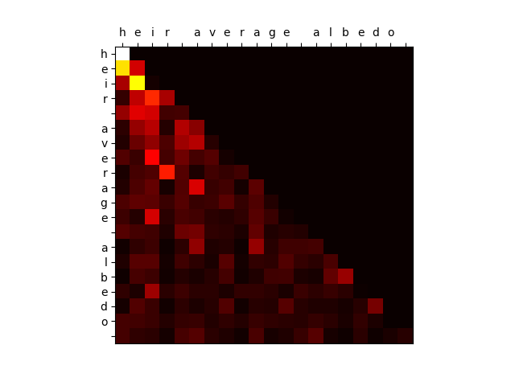

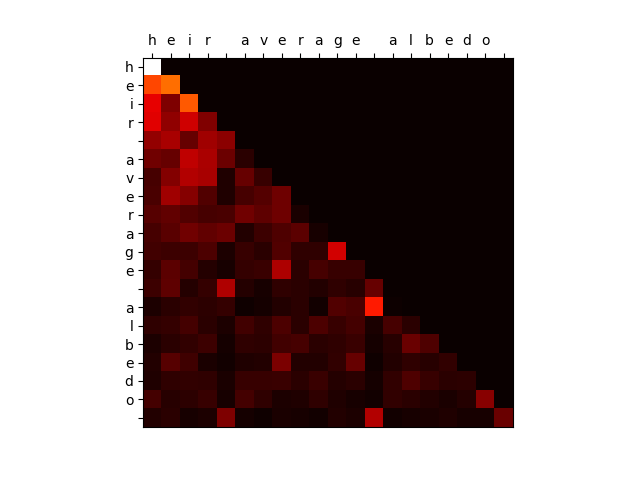

**Example 1 — `ed by rank and file`**

Layer 0

Layer 1

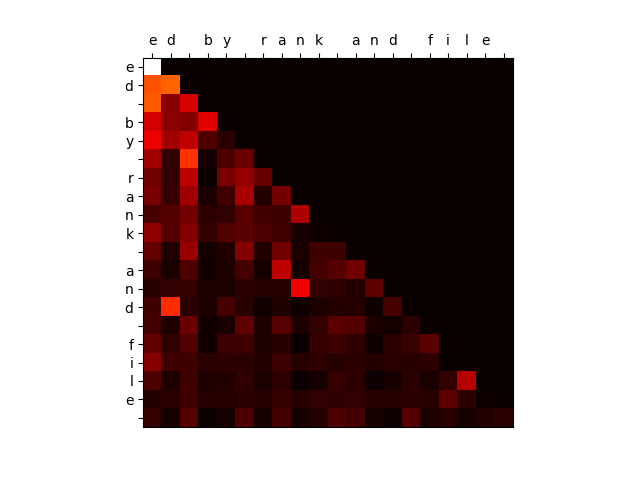

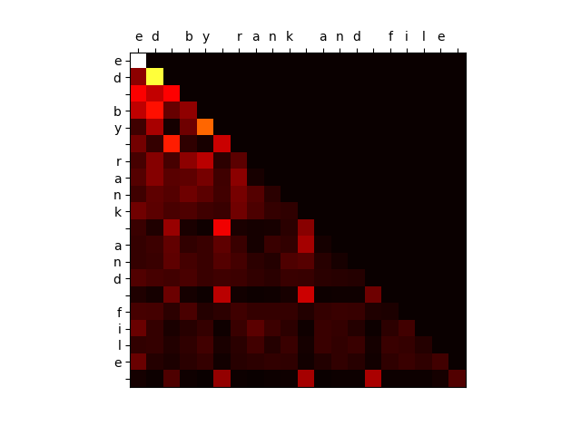

**Example 2 — `s can also extend in`**

Layer 0

Layer 1

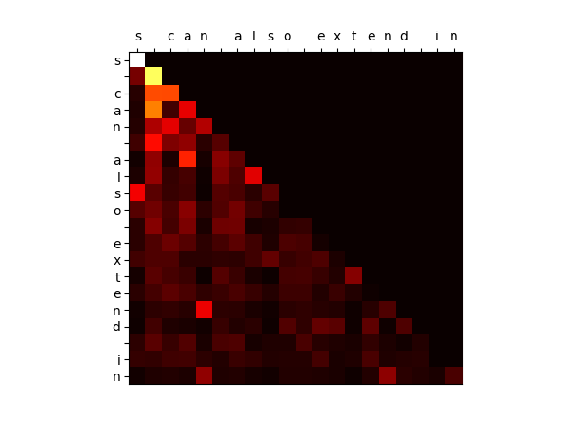

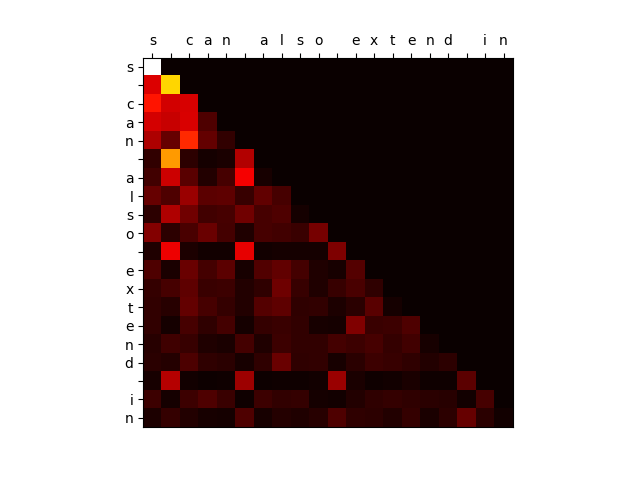

**Example 3 — `erages between nine`**

Layer 0

Layer 1

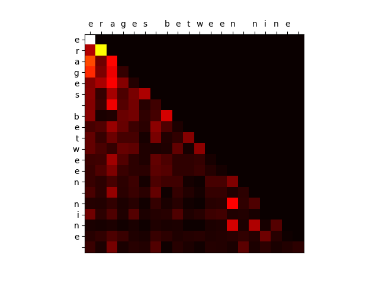

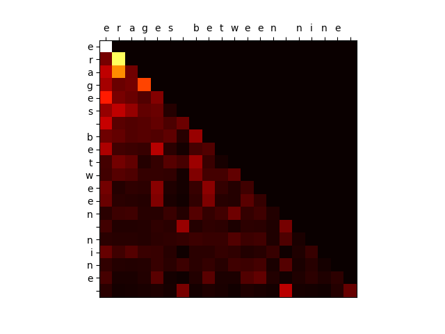

**Example 4 — `that civilization n`**

Layer 0

Layer 1

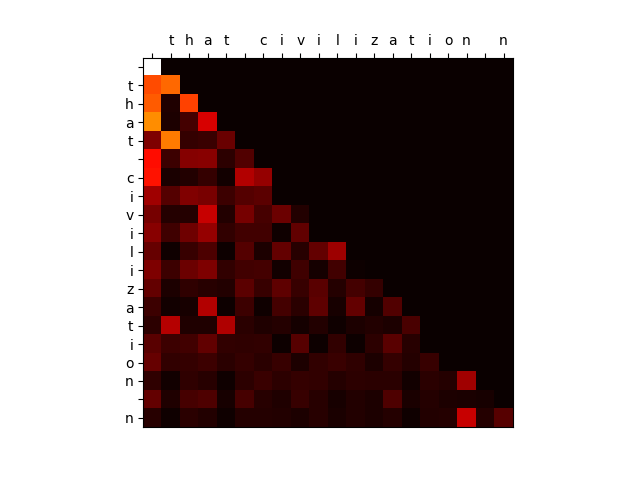

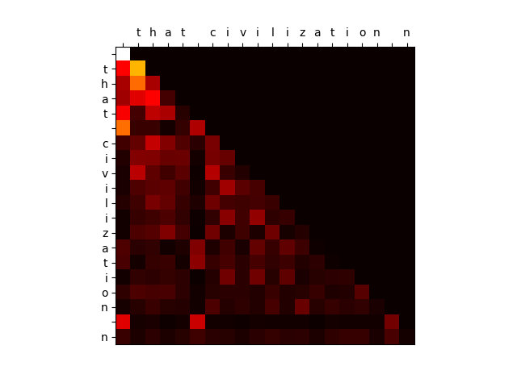

```python
!python letter_counting.py --task BEFOREAFTER
```

```
Namespace(task='BEFOREAFTER', train='data/lettercounting-train.txt', dev='data/lettercounting-dev.txt', output_bundle_path='classifier-output.json')
['a', 'b', 'c', 'd', 'e', 'f', 'g', 'h', 'i', 'j', 'k', 'l', 'm', 'n', 'o', 'p', 'q', 'r', 's', 't', 'u', 'v', 'w', 'x', 'y', 'z', ' ']
10000 lines read in
1000 lines read in
Model architecture:
Transformer(
  (tok_emb): Embedding(27, 64)
  (pos_enc): PositionalEncoding(
    (emb): Embedding(20, 64)
  )
  (layers): ModuleList(
    (0-1): 2 x TransformerLayer(
      (W_q): Linear(in_features=64, out_features=64, bias=True)
      (W_k): Linear(in_features=64, out_features=64, bias=True)
      (W_v): Linear(in_features=64, out_features=64, bias=True)
      (W_o): Linear(in_features=64, out_features=64, bias=True)
      (ln_1): LayerNorm((64,), eps=1e-05, elementwise_affine=True)
      (ln_2): LayerNorm((64,), eps=1e-05, elementwise_affine=True)
      (mlp): MLP(
        (c_fc): Linear(in_features=64, out_features=256, bias=True)
        (gelu): GELU(approximate='tanh')
        (c_proj): Linear(in_features=256, out_features=64, bias=True)
      )
    )
  )
  (ln_f): LayerNorm((64,), eps=1e-05, elementwise_affine=True)
  (head): Linear(in_features=64, out_features=3, bias=True)
)
Task: BEFOREAFTER  |  causal=False
Epoch  1 | train_loss=0.7208 | dev_acc(200 exs)=0.8327 | time=3.2s
Epoch  2 | train_loss=0.3062 | dev_acc(200 exs)=0.9177 | time=3.1s
Epoch  3 | train_loss=0.1968 | dev_acc(200 exs)=0.9475 | time=5.1s
Epoch  4 | train_loss=0.1249 | dev_acc(200 exs)=0.9630 | time=5.6s
Epoch  5 | train_loss=0.0634 | dev_acc(200 exs)=0.9892 | time=3.2s
Epoch  6 | train_loss=0.0412 | dev_acc(200 exs)=0.9912 | time=3.3s
Epoch  7 | train_loss=0.0291 | dev_acc(200 exs)=0.9960 | time=3.3s
Epoch  8 | train_loss=0.0241 | dev_acc(200 exs)=0.9938 | time=3.3s
Epoch  9 | train_loss=0.0163 | dev_acc(200 exs)=0.9942 | time=3.5s
Epoch 10 | train_loss=0.0264 | dev_acc(200 exs)=0.9975 | time=3.1s
INPUT 0: heir average albedo
GOLD 0: array([0, 2, 0, 1, 2, 2, 0, 2, 1, 2, 0, 2, 2, 2, 0, 0, 2, 0, 0, 2])
PRED 0: array([0, 2, 0, 1, 2, 2, 0, 2, 1, 2, 0, 2, 2, 2, 0, 0, 2, 0, 0, 2])
INPUT 1: ed by rank and file
GOLD 1: array([1, 1, 2, 0, 0, 2, 0, 1, 1, 0, 2, 1, 1, 1, 2, 0, 0, 0, 1, 2])
PRED 1: array([1, 1, 2, 0, 0, 2, 0, 1, 1, 0, 2, 1, 1, 1, 2, 0, 0, 0, 1, 2])
INPUT 2: s can also extend in
GOLD 2: array([1, 2, 0, 1, 2, 2, 1, 0, 1, 0, 2, 1, 0, 0, 1, 2, 0, 2, 0, 2])
PRED 2: array([1, 2, 0, 1, 2, 2, 1, 0, 1, 0, 2, 1, 0, 0, 1, 2, 0, 2, 0, 2])
INPUT 3: erages between nine
GOLD 3: array([2, 0, 0, 0, 2, 0, 2, 0, 2, 0, 0, 2, 2, 2, 2, 2, 0, 2, 2, 2])
PRED 3: array([2, 0, 0, 0, 2, 0, 2, 0, 2, 0, 0, 2, 2, 2, 2, 2, 0, 2, 2, 2])
INPUT 4:  that civilization n
GOLD 4: array([2, 2, 0, 1, 2, 2, 0, 2, 0, 2, 0, 2, 0, 1, 2, 2, 0, 1, 2, 1])
PRED 4: array([2, 2, 0, 1, 2, 2, 0, 2, 0, 2, 0, 2, 0, 1, 2, 2, 0, 1, 2, 1])
Accuracy: 100 / 100 = 1.000000
Training accuracy (100 exs):
Accuracy: 1993 / 2000 = 0.996500
Dev accuracy (whole set):
Decoding on a large number of examples (1000); not printing or plotting
Accuracy: 19925 / 20000 = 0.996250
```

## BEFOREAFTER task — Implementation summary

Same architecture as BEFORE, but the `TransformerLayer` is instantiated with `causal=False` so that every position can attend to every other position (the task requires counting all other occurrences, not only the previous ones). The attention mask is simply not applied.

### Attention visualizations — BEFOREAFTER

**Example 0 — `heir average albedo`**

Layer 0

Layer 1

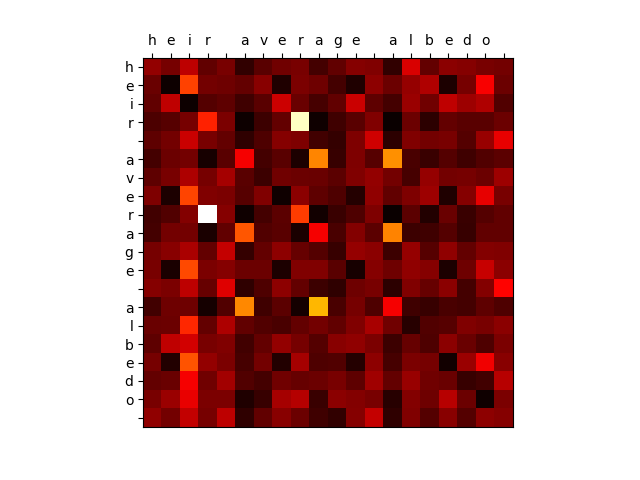

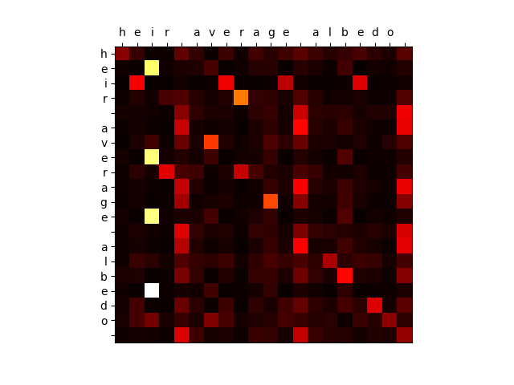

**Example 1 — `ed by rank and file`**

Layer 0

Layer 1

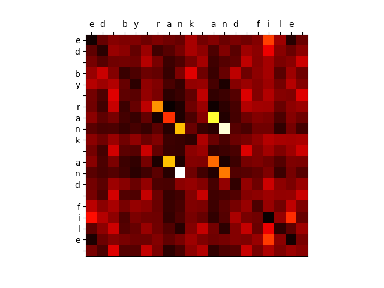

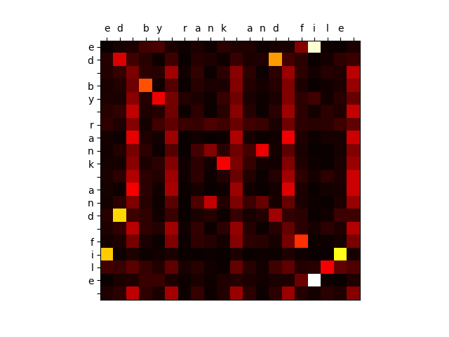

**Example 2 — `s can also extend in`**

Layer 0

Layer 1

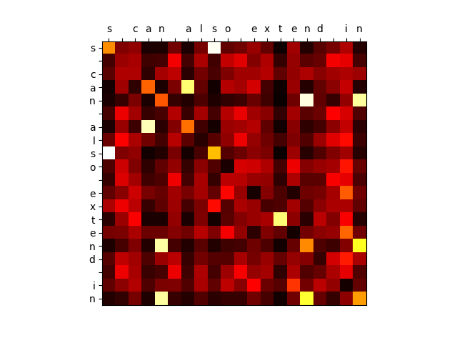

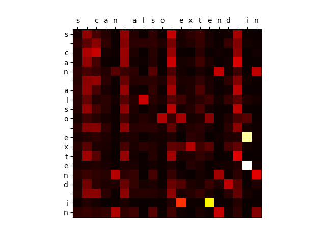

**Example 3 — `erages between nine`**

Layer 0

Layer 1

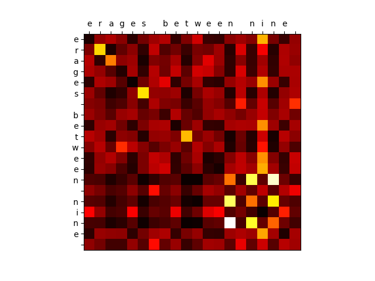

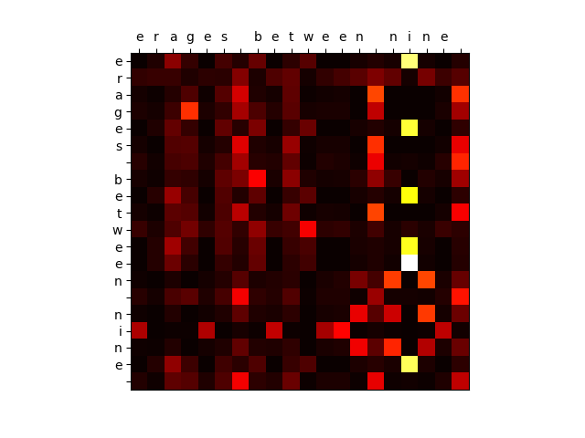

**Example 4 — `that civilization n`**

Layer 0

Layer 1

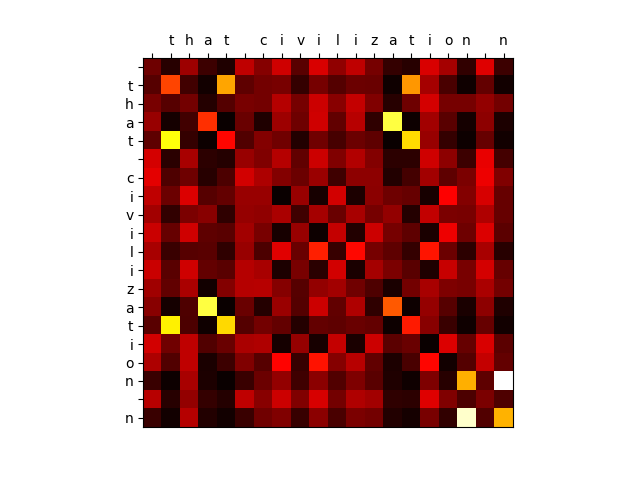

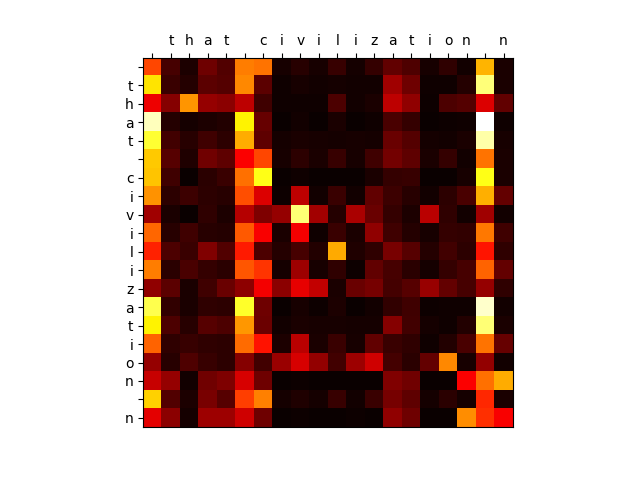

- This assignment was mainly adopted from [link](https://www.cs.utexas.edu/~gdurrett/courses/online-course/a3.pdf).

**Upload your homework: use html file format.**

```python
!jupyter nbconvert assignment-02-24300980021-刘俊彦.ipynb --to html --template classic --embed-images
```